# Numerical Methods for PDEs (Spring 2017), Lab 12

Gustav Delius, Richard Southwell

# The method of lines

The “method of lines” for parabolic equations consists of at first only discretizing the $x$ direction but leaving the time continuous. This converts the PDEs into a system of ODEs. Then one uses a well-established method for the solution of systems of ODEs to get a numerical solution.

The main advantage of this approach is that there are very good packages for solving ODEs that implement powerful methods that would be a lot of work to code from scratch. In this lab we will use the deSolve package in R.

```r
#install.packages("deSolve")
library(deSolve)
```

We will illustrate the method with the system of PDEs from Lab 11:
$$\begin{split}
\frac{\partial P}{\partial t} &= D\frac{\partial^2 P}{\partial x^2}
+h_- \frac{\partial}{\partial x}P\frac{\partial Z}{\partial x}
+\beta P(1-P)-Z\frac{P^2}{P^2+\nu^2},\\
\frac{\partial Z}{\partial t} &= D\frac{\partial^2 Z}{\partial x^2}
-h_+ \frac{\partial}{\partial x}Z\frac{\partial P}{\partial x}
+\gamma Z\left(\frac{P^2}{P^2+\nu^2}-w\right).
\end{split}$$

We perform the discretization in the x direction as usual by choosing a step size $h$ and introducing points $x_k=k h$ for $k=0,\dots, N$.

```r
h <- 0.1
N <- 400
x <- (0:N)*h
```

We will use the function `ode()` from the deSolve package. This requires us to package the right-hand side of the ODE into a function. That function takes a vector $v=(P_0,P_1,\dots,P_N,Z_0,Z_1,\dots Z_N)$ and returns a vector of the corresponding time derivatives. We can reuse code from lab 11 to write this function.

```r
f <- function(t, y, parms) {
    N <- length(y)/2-1

    P <- y[1:(N+1)]
    Pp <- c(P[2:(N+1)], P[N])
    Pm <- c(P[2], P[1:N])

    Z <- y[(N+2):length(y)]
    Zp <- c(Z[2:(N+1)], Z[N-1])
    Zm <- c(Z[2], Z[1:N])

    Pd <- D/h^2 * (Pp - 2*P + Pm) +
        hm/(2*h^2) * ((Pp+P)*(Zp-Z)-(P+Pm)*(Z-Zm)) +
        beta*P*(1-P)-Z*P^2/(P^2+nu^2)

    Zd <- D/h^2 * (Zp - 2*Z + Zm) -
        hp/(2*h^2) * ((Zp+Z)*(Pp-P)-(Z+Zm)*(P-Pm)) +
        gamma*Z*(P^2/(P^2+nu^2) - w)

    list(c(Pd, Zd))
}
```

The reason we gave the function `f()` the arguments `t` and `parms` even though they are not used is that this is the form that `ode()` expects. This is also the reason why we wrapped the returned vector of time derivatives in a `list()`.

We also need to create a vector of times at which we want `ode()` to return values.

```r
t <- (0:100)*4
```

We choose parameter values

```r
D <- 0.04
nu <- 0.07
beta <- 1
gamma <- 0.01
w <- 0.004/gamma
hp <- 0
hm <- 0
```

and create a vector containing the initial values:

```r
P0 <- uniroot(function(P) P^2/(P^2+nu^2)-w, interval=c(0,1))$root
Z0 <- beta*P0*(1-P0)/w
Pn <- P0 + ifelse(x<1/4, 0.2*(cos(4*pi*x)+1), 0)
Zn <- Z0 + 0*x
y0 <- c(Pn, Zn)
```

We can now call the `ode()` function to obtain the solution.

```r
sol <- ode(y0, t, f, parms=NULL)
```

We extract the P and Z values from the returned array.

```r
P <- t(sol[, 2:(N+2)])
Z <- t(sol[, (N+3):(2*N+3)])
```

Now we can plot the prey abundance

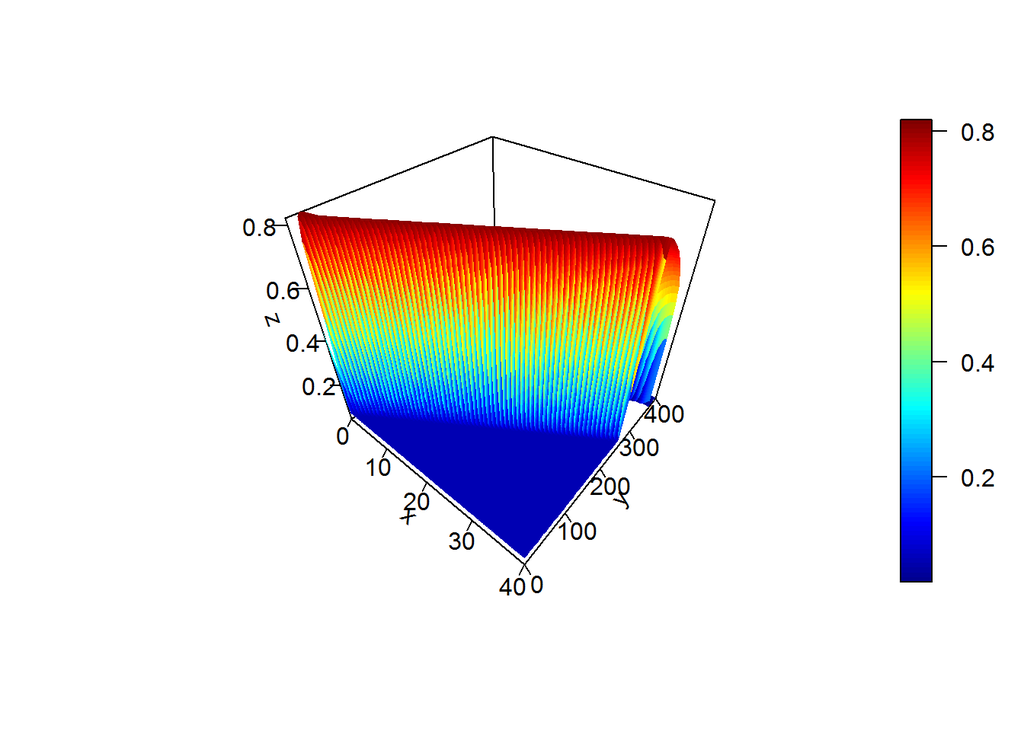

```r
library(plot3Drgl)
persp3D(x, t, P,
        ticktype="detailed", nticks=4)
```

```r
plotrgl(lighting = TRUE, smooth = TRUE)
```

and the predator abundance

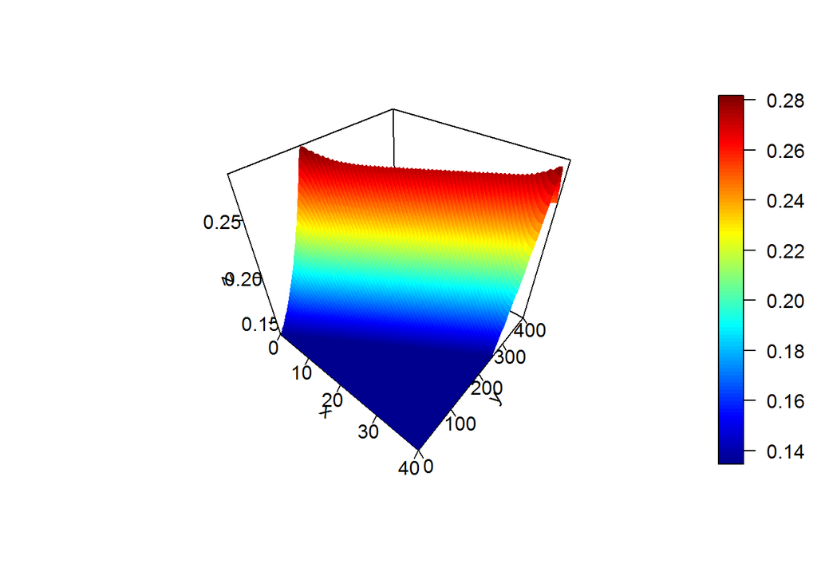

```r
persp3D(x, t, Z,
        ticktype="detailed", nticks=4)
```

```r
plotrgl(lighting = TRUE, smooth = TRUE)
```

and the profile of both at an intermediate time:

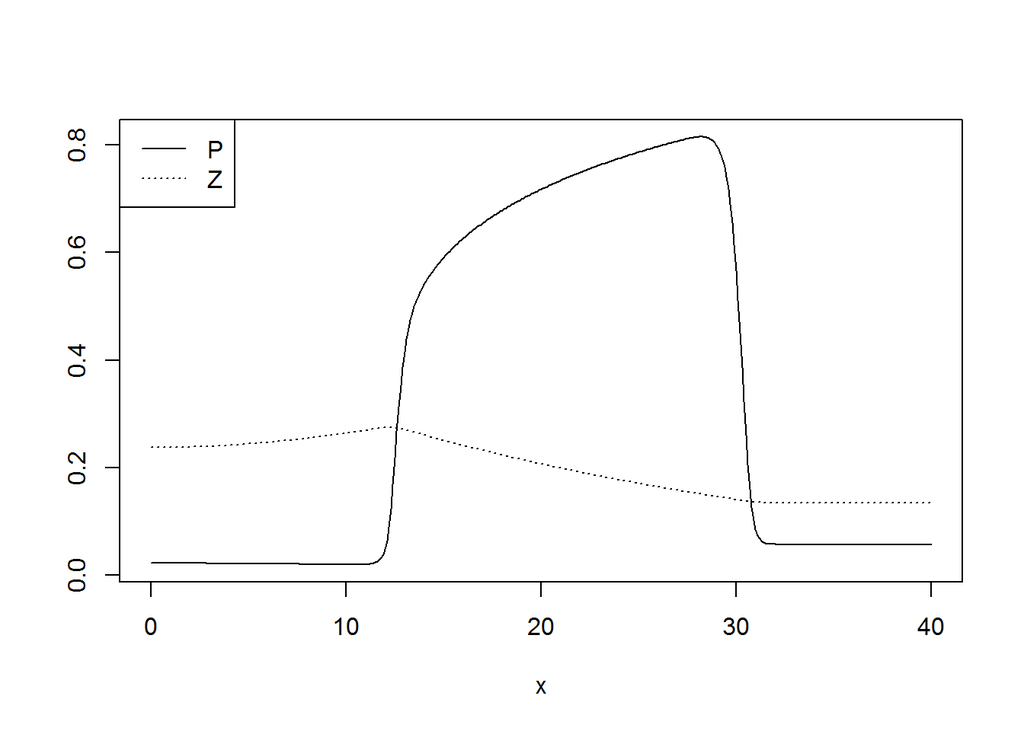

```r
plot(x, P[, 51], type="l", ylab="")
lines(x, Z[, 51], lty="dotted")
legend("topleft", legend=c("P", "Z"), lty=c("solid", "dotted"))
```

This agrees with the corresponding plots from Lab 11.

Next we go to the parameter values that created stability issues in Lab 11.

```r
hp <- 0.9
N <- 520
x <- (0:N)/4
t <- (0:100)*3.9
Pn <- P0 + ifelse(x<1, 0.4*(cos(pi*x)+1), 0)
Zn <- Z0 + 0*x
y0 <- c(Pn, Zn)

sol <- ode(y0, t, f, parms=NULL)
P <- t(sol[, 2:(N+2)])
Z <- t(sol[, (N+3):(2*N+3)])
```

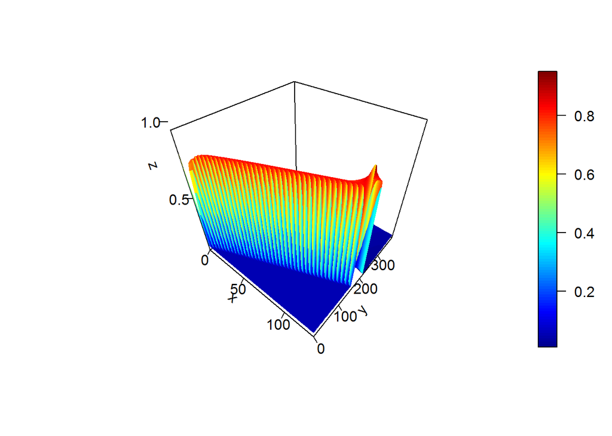

```r
persp3D(x, t, P,
        ticktype="detailed", nticks=4)
```

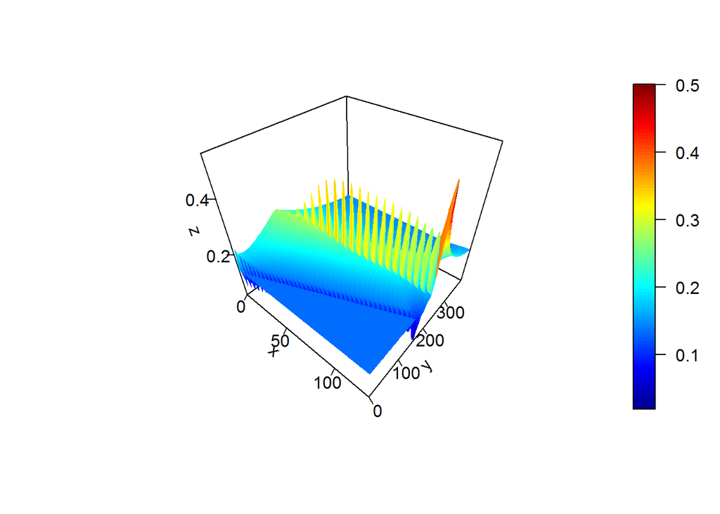

```r
persp3D(x, t, Z,
        ticktype="detailed", nticks=4)
```

```r
plotrgl(lighting = TRUE, smooth = TRUE)
```